# Introduction to decision trees using rpart package

Hicham Zmarrou

2017-12-12

## Stage C prostate cancer

- Example is based on a data set of 146 stage C prostate cancer patients.
- Main clinical endpoint of interest is:
- whether the disease recurs after initial surgical removal of the prostate, and
- the time interval to that progression (if any).
- The target variable in this example is status, which takes on the value 1 if the disease has progressed and 0 if not.
- The main predictor variable of interest in this study was DNA ploidy, as determined by experimental studies.
- A short description of each of the variables is listed below.

```
pgtime: Time to progression or last follow-up (years)

pgstat: 1 = progression observed, 0 = censored

age: age in years

eet: early endocrine therapy, 1 = no, 2 = yes

g2: percent of cells in G2 phase, as found by flow cytometry

grade: grade of the tumor, Farrow system

gleason: grade of the tumor, Gleason system

ploidy: the ploidy status of the tumor, from flow cytometry. Values are diploid, tetraploid, and aneuploid
```

### Explore the data by plotting

1. plotting progression rate by value of ploidy;

```r
# count the number of  1 = progression observed, and 0 = censored in the pgstat variable
stagec %>%
  group_by(pgstat) %>%
  summarize(count =n()) %>%
  mutate(freq = count / sum(count))
```

| pgstat | count | freq |
| --- | --- | --- |
| 0 | 92 | 0.630137 |
| 1 | 54 | 0.369863 |

```r
(counts_pldy <- stagec %>%
  group_by(pgstat,ploidy) %>%
  summarize(count =n()) )
```

| pgstat | ploidy | count |
| --- | --- | --- |
| 0 | diploid | 54 |
| 0 | tetraploid | 34 |
| 0 | aneuploid | 4 |
| 1 | diploid | 13 |
| 1 | tetraploid | 34 |
| 1 | aneuploid | 7 |

```r
#(counts <- table(clean_titanic$survived, clean_titanic$sex))
#barplot(counts, xlab = "Gender", ylab = "Number of People", main = "survived and deceased per gender")
```

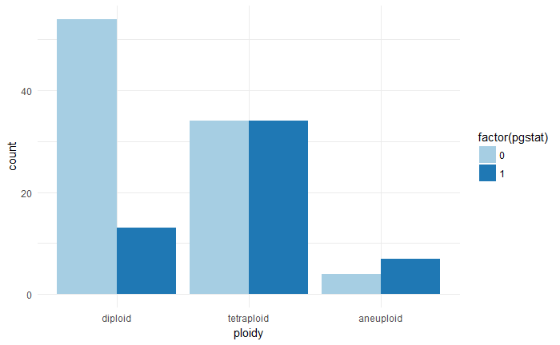

```r
ggplot(data=counts_pldy, aes(x=ploidy,y=count,fill=factor(pgstat))) +
  geom_bar(stat="identity", position=position_dodge())+
  #geom_text(aes(y=label_ypos, label=len), vjust=1.6,
   #         color="white", size=3.5)+
  scale_fill_brewer(palette="Paired")+
  theme_minimal()
```

2. Claculate the progression rate by value ofearly endocrine therapy;

```r
(counts_eet <- stagec %>%
  group_by(pgstat,eet) %>%
  summarize(count =n()) )
```

| pgstat | eet | count |
| --- | --- | --- |
| 0 | 1 | 22 |
| 0 | 2 | 70 |
| 1 | 1 | 14 |
| 1 | 2 | 38 |
| 1 | NA | 2 |

```r
#(counts <- table(clean_titanic$survived, clean_titanic$sex))
#barplot(counts, xlab = "Gender", ylab = "Number of People", main = "survived and deceased per gender")
```

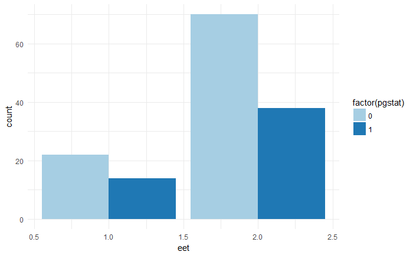

```r
ggplot(data=counts_eet, aes(x=eet,y=count,fill=factor(pgstat))) +
  geom_bar(stat="identity", position=position_dodge())+
  #geom_text(aes(y=label_ypos, label=len), vjust=1.6,
   #         color="white", size=3.5)+
  scale_fill_brewer(palette="Paired")+
  theme_minimal()
```

### Fitting a decision tree

```r
progstat <- factor(stagec$pgstat, levels = 0:1, labels = c("No", "Prog"))
cfit <- rpart(progstat ~ age + eet + g2 + grade + gleason + ploidy,
data = stagec, method = 'class')
print(cfit)
```

```
n= 146

node), split, n, loss, yval, (yprob)
      * denotes terminal node

 1) root 146 54 No (0.6301370 0.3698630)
   2) grade< 2.5 61  9 No (0.8524590 0.1475410) *
   3) grade>=2.5 85 40 Prog (0.4705882 0.5294118)
     6) g2< 13.2 40 17 No (0.5750000 0.4250000)
      12) ploidy=diploid,tetraploid 31 11 No (0.6451613 0.3548387)
        24) g2>=11.845 7  1 No (0.8571429 0.1428571) *
        25) g2< 11.845 24 10 No (0.5833333 0.4166667)
          50) g2< 11.005 17  5 No (0.7058824 0.2941176) *
          51) g2>=11.005 7  2 Prog (0.2857143 0.7142857) *
      13) ploidy=aneuploid 9  3 Prog (0.3333333 0.6666667) *
     7) g2>=13.2 45 17 Prog (0.3777778 0.6222222)
      14) g2>=17.91 22  8 No (0.6363636 0.3636364)
        28) age>=62.5 15  4 No (0.7333333 0.2666667) *
        29) age< 62.5 7  3 Prog (0.4285714 0.5714286) *
      15) g2< 17.91 23  3 Prog (0.1304348 0.8695652) *
```

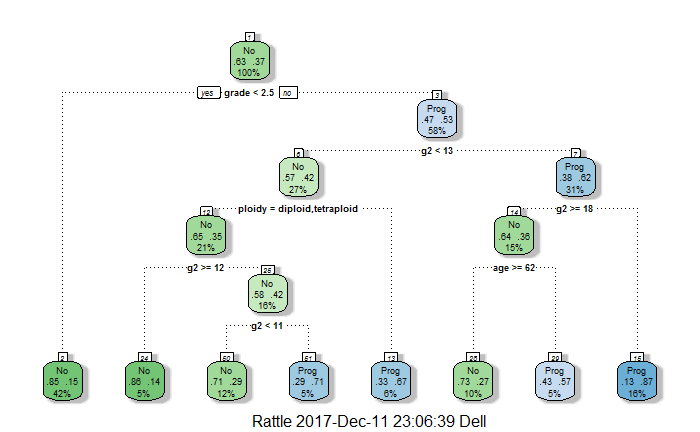

```r
 library(rattle)
 library(rpart.plot)
 library(RColorBrewer)
fancyRpartPlot(cfit)
```

```r
asRules(cfit)
```

```
 Rule number: 15 [progstat=Prog cover=23 (16%) prob=0.87]
   grade>=2.5
   g2>=13.2
   g2< 17.91

 Rule number: 51 [progstat=Prog cover=7 (5%) prob=0.71]
   grade>=2.5
   g2< 13.2
   ploidy=diploid,tetraploid
   g2< 11.84
   g2>=11

 Rule number: 13 [progstat=Prog cover=9 (6%) prob=0.67]
   grade>=2.5
   g2< 13.2
   ploidy=aneuploid

 Rule number: 29 [progstat=Prog cover=7 (5%) prob=0.57]
   grade>=2.5
   g2>=13.2
   g2>=17.91
   age< 62.5

 Rule number: 50 [progstat=No cover=17 (12%) prob=0.29]
   grade>=2.5
   g2< 13.2
   ploidy=diploid,tetraploid
   g2< 11.84
   g2< 11

 Rule number: 28 [progstat=No cover=15 (10%) prob=0.27]
   grade>=2.5
   g2>=13.2
   g2>=17.91
   age>=62.5

 Rule number: 2 [progstat=No cover=61 (42%) prob=0.15]
   grade< 2.5

 Rule number: 24 [progstat=No cover=7 (5%) prob=0.14]
   grade>=2.5
   g2< 13.2
   ploidy=diploid,tetraploid
   g2>=11.84
```

```r
printcp(cfit)
```

```
Classification tree:
rpart(formula = progstat ~ age + eet + g2 + grade + gleason +
    ploidy, data = stagec, method = "class")

Variables actually used in tree construction:
[1] age    g2     grade  ploidy

Root node error: 54/146 = 0.36986

n= 146

        CP nsplit rel error  xerror    xstd
1 0.104938      0   1.00000 1.00000 0.10802
2 0.055556      3   0.68519 1.12963 0.11036
3 0.027778      4   0.62963 0.92593 0.10618
4 0.018519      6   0.57407 0.94444 0.10668
5 0.010000      7   0.55556 0.94444 0.10668
```

```r
summary(cfit, cp=0.06)
```

```
Call:
rpart(formula = progstat ~ age + eet + g2 + grade + gleason +
    ploidy, data = stagec, method = "class")
  n= 146

          CP nsplit rel error    xerror      xstd
1 0.10493827      0 1.0000000 1.0000000 0.1080241
2 0.05555556      3 0.6851852 1.1296296 0.1103581
3 0.02777778      4 0.6296296 0.9259259 0.1061819
4 0.01851852      6 0.5740741 0.9444444 0.1066785
5 0.01000000      7 0.5555556 0.9444444 0.1066785

Variable importance
     g2   grade gleason  ploidy     age     eet
     30      28      20      13       7       2

Node number 1: 146 observations,    complexity param=0.1049383
  predicted class=No    expected loss=0.369863  P(node) =1
    class counts:    92    54
   probabilities: 0.630 0.370
  left son=2 (61 obs) right son=3 (85 obs)
  Primary splits:
      grade   < 2.5    to the left,  improve=10.357590, (0 missing)
      gleason < 5.5    to the left,  improve= 8.399574, (3 missing)
      ploidy  splits as  LRR,        improve= 7.656533, (0 missing)
      g2      < 13.2   to the left,  improve= 7.186766, (7 missing)
      age     < 58.5   to the right, improve= 1.388128, (0 missing)
  Surrogate splits:
      gleason < 5.5    to the left,  agree=0.863, adj=0.672, (0 split)
      ploidy  splits as  LRR,        agree=0.644, adj=0.148, (0 split)
      g2      < 9.945  to the left,  agree=0.630, adj=0.115, (0 split)
      age     < 66.5   to the right, agree=0.589, adj=0.016, (0 split)

Node number 2: 61 observations
  predicted class=No    expected loss=0.147541  P(node) =0.4178082
    class counts:    52     9
   probabilities: 0.852 0.148

Node number 3: 85 observations,    complexity param=0.1049383
  predicted class=Prog  expected loss=0.4705882  P(node) =0.5821918
```

[output cut: 29 more lines]

```
  Surrogate splits:
      age     < 61.5   to the right, agree=0.614, adj=0.190, (1 split)
      eet     < 1.5    to the right, agree=0.591, adj=0.143, (0 split)
      grade   < 3.5    to the right, agree=0.545, adj=0.048, (0 split)
      gleason < 6.5    to the right, agree=0.545, adj=0.048, (0 split)

Node number 14: 22 observations
  predicted class=No    expected loss=0.3636364  P(node) =0.1506849
    class counts:    14     8
   probabilities: 0.636 0.364

Node number 15: 23 observations
  predicted class=Prog  expected loss=0.1304348  P(node) =0.1575342
    class counts:     3    20
   probabilities: 0.130 0.870
```